# A2

Zoe Zhou

29/03/2020

### Question 1. Use the Holt-Winters technique to build a model.

```r
(HW.CO2 = HoltWinters(reduced.CO2.ts))
```

```
## Holt-Winters exponential smoothing with trend and additive seasonal component.
##
## Call:
## HoltWinters(x = reduced.CO2.ts)
##
## Smoothing parameters:
##  alpha: 0.9267355
##  beta : 0.0813906
##  gamma: 1
##
## Coefficients:
##           [,1]
## a  405.1011655
## b    0.5889777
## s1   0.2311236
## s2  -0.2791367
## s3  -0.2150001
## s4   0.4588345
```

#### Prediction

```r
# Predict for the next 4 quarters
(HW.CO2.pred = predict(HW.CO2, n.ahead = 4))
```

```
##          Qtr1     Qtr2     Qtr3     Qtr4
## 2018                            405.9213
## 2019 406.0000 406.6531 407.9159
```

```r
# Compare to actual values
(actual = CO2.ts[(length(CO2.ts) - 3):length(CO2.ts)])
```

```
## [1] 405.83 405.73 406.71 408.25
```

#### RMSEP

```r
(RMSEP.HW.pred = sqrt(1/4 * sum((actual - HW.CO2.pred) ^ 2)))
```

```
## [1] 0.2214015
```

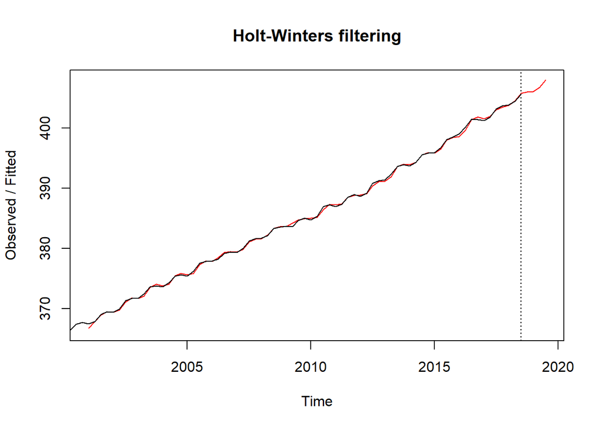

```r
plot(HW.CO2, HW.CO2.pred)
```

#### Comment:

The model did a pretty good job at prediction as we can see very small differences between the predicted and actual line. The predicted values are very close to the actual values. The prediction error is pretty small (0.2214 ppm).

### Question 2. Using the de-seasonalising techniques (Moving Averages and Seasonal Trend Lowess), build Seasonally Adjusted models of the data (2000 to 2018.3).

#### Use Moving Average to de-seasonalise data

```
## [1] -0.3537786 -0.3024142  0.4383742  0.2178186
```

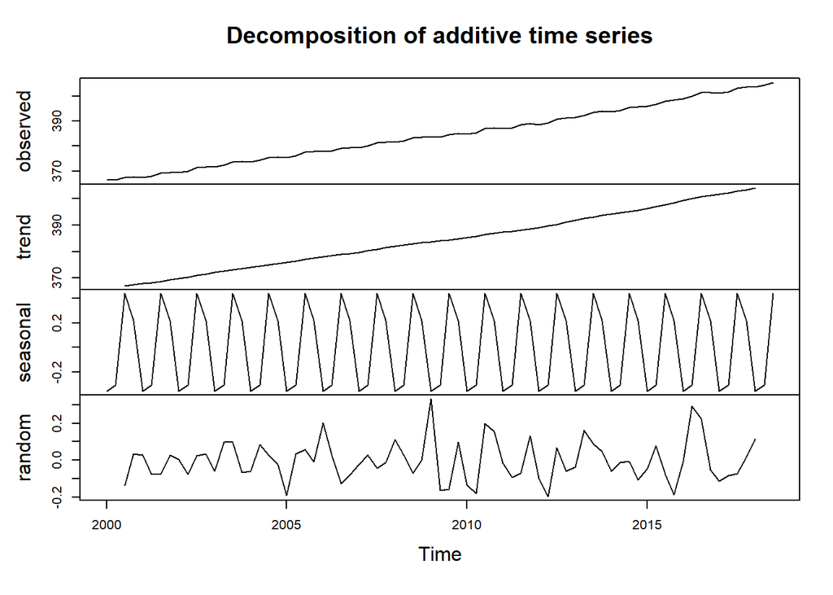

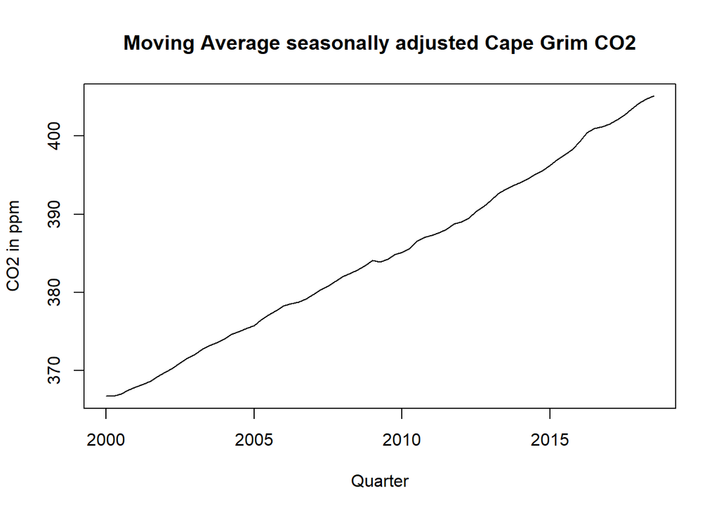

```
##  [1]  1  2  3  4  5  6  7  8  9 10 11 12 13 14 15 16 17 18 19 20 21 22 23
## [24] 24 25 26 27 28 29 30 31 32 33 34 35 36 37 38 39 40 41 42 43 44 45 46
## [47] 47 48 49 50 51 52 53 54 55 56 57 58 59 60 61 62 63 64 65 66 67 68 69
## [70] 70 71 72 73 74 75
```

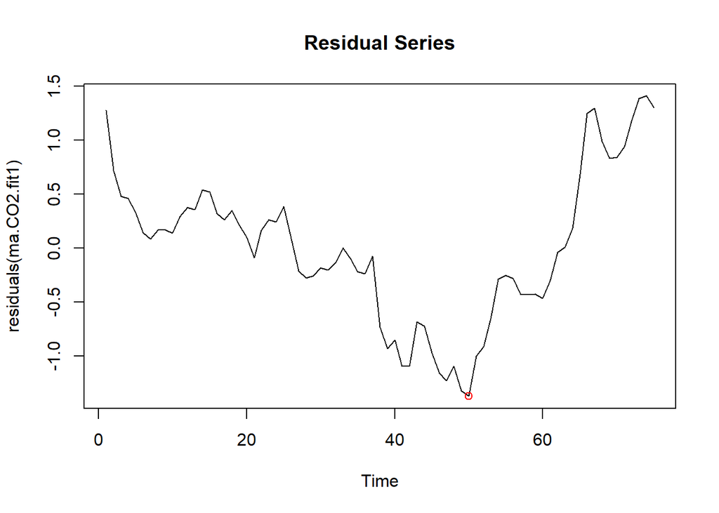

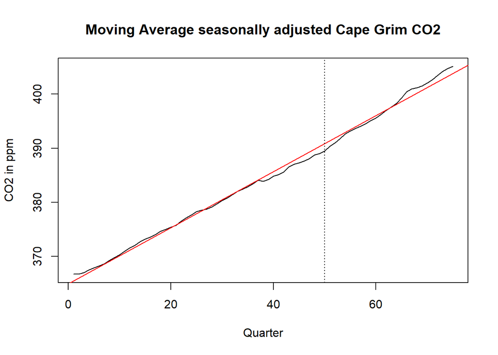

```
##
## Call:
## lm(formula = ma.sa.CO2.ts ~ Time)
##
## Residuals:
##      Min       1Q   Median       3Q      Max
## -1.37205 -0.42815  0.00902  0.36547  1.40830
##
## Coefficients:
##              Estimate Std. Error t value Pr(>|t|)
## (Intercept) 3.649e+02  1.643e-01  2220.7   <2e-16 ***
## Time        5.183e-01  3.758e-03   137.9   <2e-16 ***
## ---
## Signif. codes:  0 '***' 0.001 '**' 0.01 '*' 0.05 '.' 0.1 ' ' 1
##
## Residual standard error: 0.7045 on 73 degrees of freedom
## Multiple R-squared:  0.9962, Adjusted R-squared:  0.9961
## F-statistic: 1.903e+04 on 1 and 73 DF,  p-value: < 2.2e-16
```

```
##
## Call:
## lm(formula = ma.sa.CO2.ts ~ Time + Time.break)
##
## Residuals:
##     Min      1Q  Median      3Q     Max
## -0.4695 -0.2097 -0.0187  0.2027  0.6654
##
## Coefficients:
##              Estimate Std. Error t value Pr(>|t|)
## (Intercept) 3.658e+02  7.532e-02 4856.20   <2e-16 ***
## Time        4.810e-01  2.345e-03  205.07   <2e-16 ***
## Time.break  1.393e-01  6.853e-03   20.33   <2e-16 ***
## ---
## Signif. codes:  0 '***' 0.001 '**' 0.01 '*' 0.05 '.' 0.1 ' ' 1
##
## Residual standard error: 0.2732 on 72 degrees of freedom
## Multiple R-squared:  0.9994, Adjusted R-squared:  0.9994
## F-statistic: 6.345e+04 on 2 and 72 DF,  p-value: < 2.2e-16
```

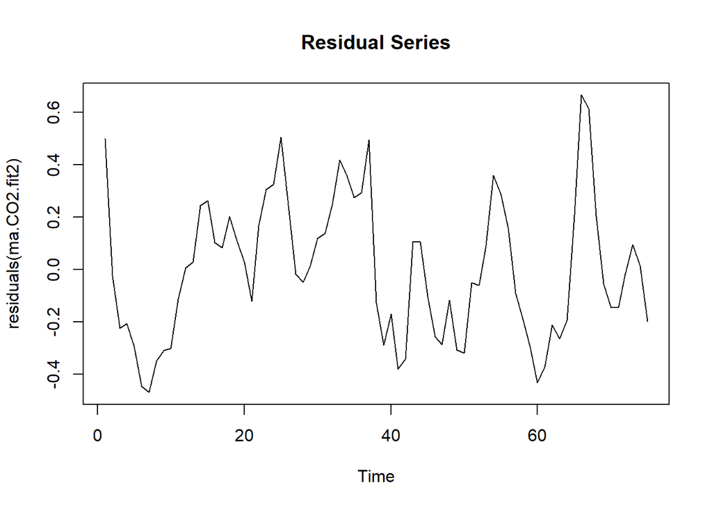

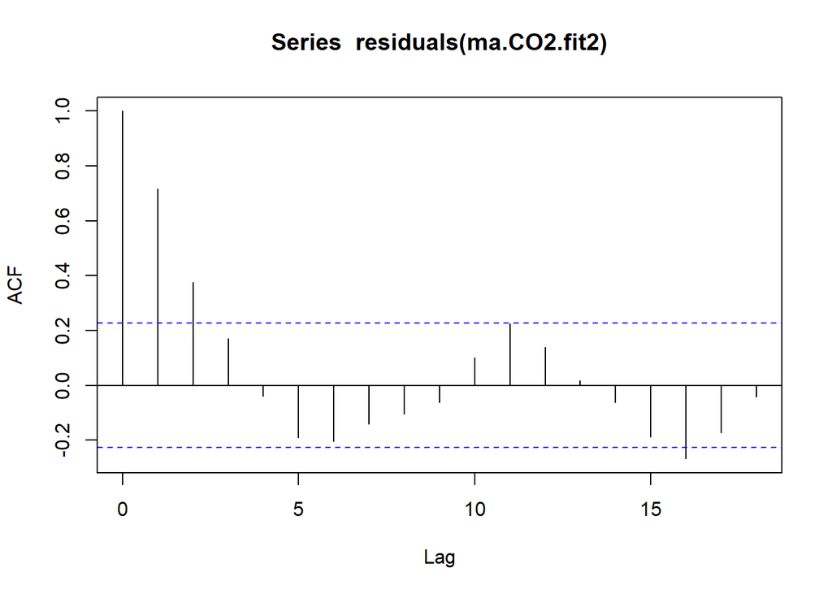

```
##
## Call:
## lm(formula = ma.sa.CO2.ts[-1] ~ Time[-1] + Time.break[-1] + ma.sa.CO2.ts[-75])
##
## Residuals:
##      Min       1Q   Median       3Q      Max
## -0.49708 -0.12360 -0.00111  0.11456  0.53291
##
## Coefficients:
##                    Estimate Std. Error t value Pr(>|t|)
## (Intercept)       109.60178   28.73023   3.815 0.000291 ***
## Time[-1]            0.14586    0.03774   3.865 0.000246 ***
## Time.break[-1]      0.04186    0.01170   3.578 0.000633 ***
## ma.sa.CO2.ts[-75]   0.70111    0.07865   8.915 3.79e-13 ***
## ---
## Signif. codes:  0 '***' 0.001 '**' 0.01 '*' 0.05 '.' 0.1 ' ' 1
##
## Residual standard error: 0.1849 on 70 degrees of freedom
## Multiple R-squared:  0.9997, Adjusted R-squared:  0.9997
## F-statistic: 8.928e+04 on 3 and 70 DF,  p-value: < 2.2e-16
```

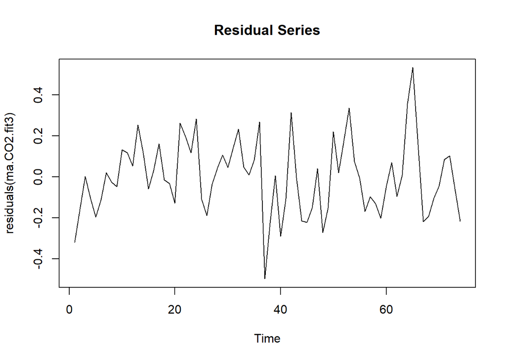

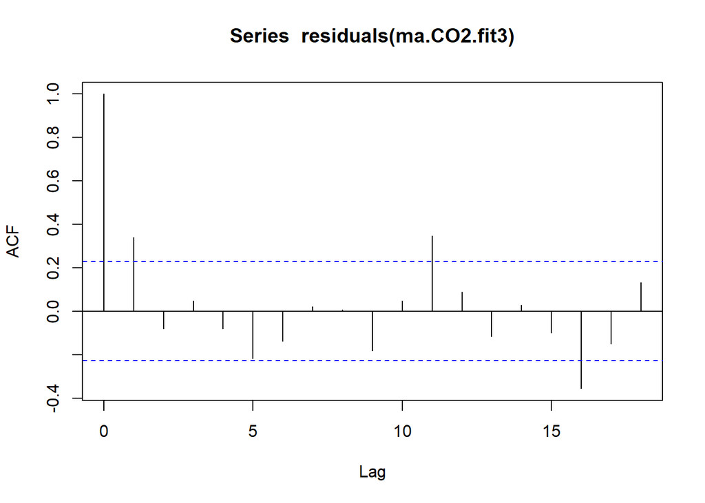

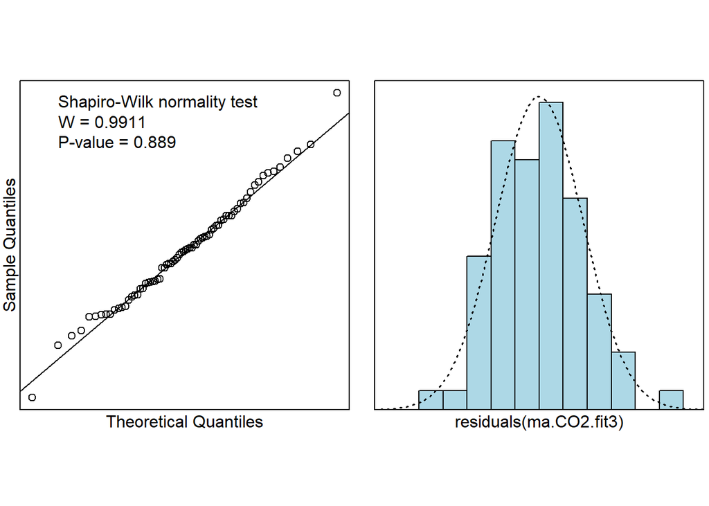

```
##
## Call:
## lm(formula = ma.sa.CO2.ts[-1] ~ Time[-1] + Time.break[-1] + ma.sa.CO2.ts[-75])
##
## Residuals:
##      Min       1Q   Median       3Q      Max
## -0.49708 -0.12360 -0.00111  0.11456  0.53291
##
## Coefficients:
##                    Estimate Std. Error t value Pr(>|t|)
## (Intercept)       109.60178   28.73023   3.815 0.000291 ***
## Time[-1]            0.14586    0.03774   3.865 0.000246 ***
## Time.break[-1]      0.04186    0.01170   3.578 0.000633 ***
## ma.sa.CO2.ts[-75]   0.70111    0.07865   8.915 3.79e-13 ***
## ---
## Signif. codes:  0 '***' 0.001 '**' 0.01 '*' 0.05 '.' 0.1 ' ' 1
##
## Residual standard error: 0.1849 on 70 degrees of freedom
## Multiple R-squared:  0.9997, Adjusted R-squared:  0.9997
## F-statistic: 8.928e+04 on 3 and 70 DF,  p-value: < 2.2e-16
```

```
## [1] 0.2327083
```

#### Seasonal Tread Lowess

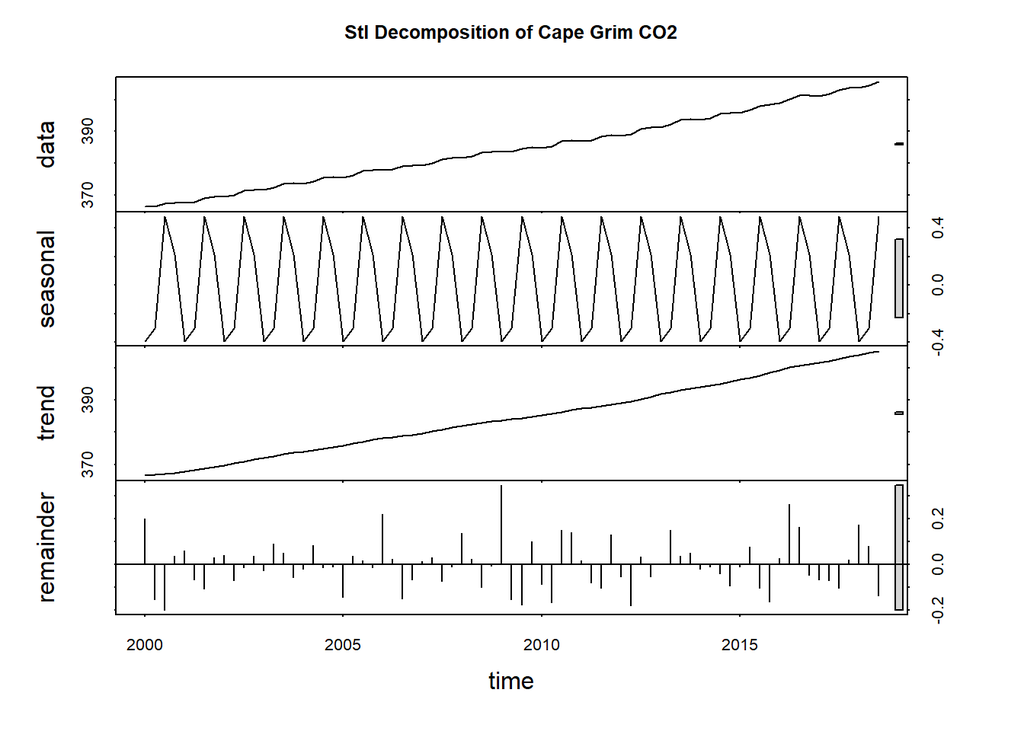

```r
# Seasonal estimates
decomp.stl.CO2$time.series[1:4, 1]
```

```
## [1] -0.3906880 -0.3028320  0.4787971  0.2147230
```

#### Comments:

The seasonal estimates from stl decomposition are showed above. We can see that, on average Quarter 1 has the smallest value of CO2 concentration while Quarter 3 has the largest.

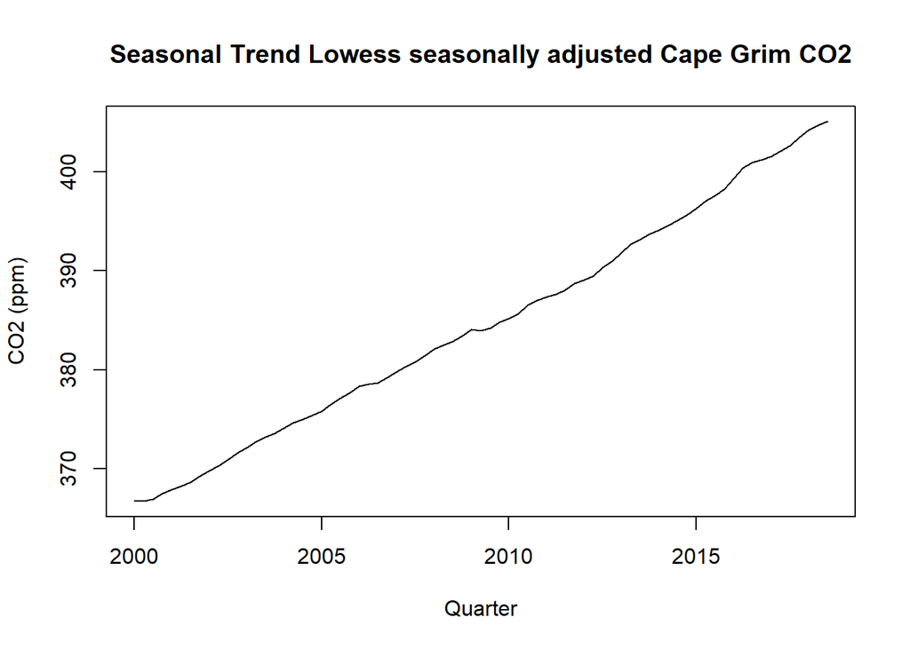

```r
# Subtract seasonal component
stl.sa.CO2.ts = reduced.CO2.ts - decomp.stl.CO2$time.series[, 1]
plot(stl.sa.CO2.ts, main = "Seasonal Trend Lowess seasonally adjusted Cape Grim CO2",
     xlab = "Quarter", ylab = "CO2 (ppm)")
```

#### Comment:

After removing the seasonal components, we can see a clear positive linear trend. Interestingly there are some small bumps in the data. We possibly have a “break” - change in slope somehwere around 2010.

#### Fit the best predicting model.

```r
stl.CO2.fit3 = lm(stl.sa.CO2.ts[-1] ~ Time[-1] + Time.break[-1] + stl.sa.CO2.ts[-75])
summary(stl.CO2.fit3)
```

```
##
## Call:
## lm(formula = stl.sa.CO2.ts[-1] ~ Time[-1] + Time.break[-1] +
##     stl.sa.CO2.ts[-75])
##
## Residuals:
##      Min       1Q   Median       3Q      Max
## -0.51687 -0.13691  0.01665  0.11813  0.51237
##
## Coefficients:
##                     Estimate Std. Error t value Pr(>|t|)
## (Intercept)        113.68138   29.12337   3.903 0.000216 ***
## Time[-1]             0.15131    0.03826   3.955 0.000181 ***
## Time.break[-1]       0.04304    0.01189   3.620 0.000554 ***
## stl.sa.CO2.ts[-75]   0.68994    0.07972   8.654 1.14e-12 ***
## ---
## Signif. codes:  0 '***' 0.001 '**' 0.01 '*' 0.05 '.' 0.1 ' ' 1
##
## Residual standard error: 0.189 on 70 degrees of freedom
## Multiple R-squared:  0.9997, Adjusted R-squared:  0.9997
## F-statistic: 8.543e+04 on 3 and 70 DF,  p-value: < 2.2e-16
```

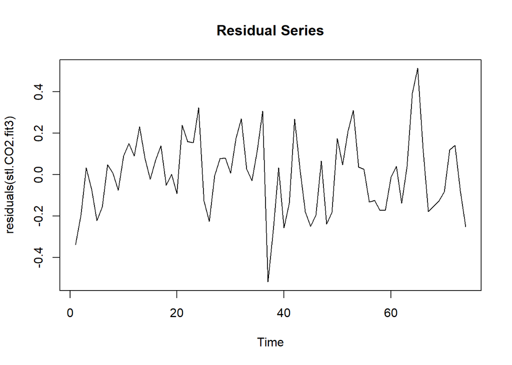

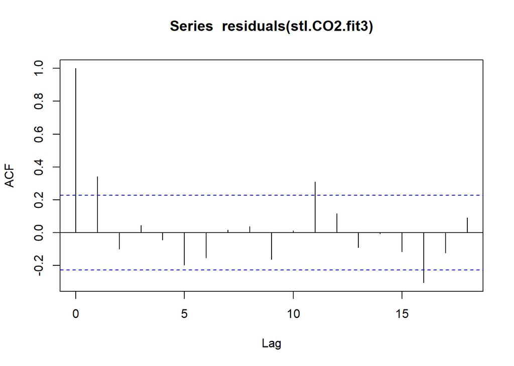

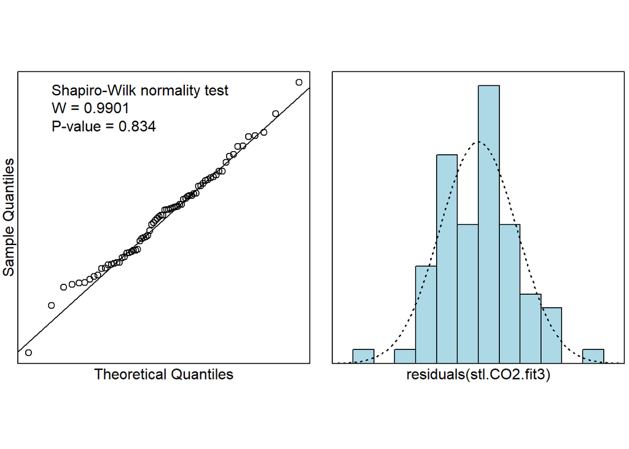

#### Prediction

```r
t76.sa.pred = stl.CO2.fit3$coef[1] + stl.CO2.fit3$coef[2] * 76 +
          stl.CO2.fit3$coef[3] * (76 - 50) + stl.CO2.fit3$coef[4] * stl.sa.CO2.ts[76 - 1]
t76.pred = t76.sa.pred + decomp.stl.CO2$time.series[4, 1]

t77.sa.pred = stl.CO2.fit3$coef[1] + stl.CO2.fit3$coef[2] * 77 +
          stl.CO2.fit3$coef[3] * (77 - 50) + stl.CO2.fit3$coef[4] * t76.sa.pred
t77.pred = t77.sa.pred + decomp.stl.CO2$time.series[1, 1]


t78.sa.pred = stl.CO2.fit3$coef[1] + stl.CO2.fit3$coef[2] * 78 +
          stl.CO2.fit3$coef[3] * (78 - 50) + stl.CO2.fit3$coef[4] * t77.sa.pred
t78.pred = t78.sa.pred + decomp.stl.CO2$time.series[2, 1]


t79.sa.pred = stl.CO2.fit3$coef[1] + stl.CO2.fit3$coef[2] * 79 +
          stl.CO2.fit3$coef[3] * (79 - 50) + stl.CO2.fit3$coef[4] * t78.sa.pred
t79.pred = t79.sa.pred + decomp.stl.CO2$time.series[3, 1]

stl.pred = c(t76.pred, t77.pred, t78.pred, t79.pred)
```

#### Calculate RMSEP to compare actual values and predicted values

```r
(RMSEP.stl.pred = sqrt(1/4 * sum((actual - stl.pred) ^ 2)))
```

```
## [1] 0.1951761
```

### Question 3. Technical Notes.

The seasonal estimates show that for the last 2 quarters, the CO2 concentration is above the overall trend with Quarter 3 being the largest(0.48 ppm). And for the first 2 quarters, the CO2 concentration is below the overall trend with Quarter 1 being the lowest (-0.39 ppm).

The plot of the seasonally adjusted data shows a clear positive linear trend. Interestingly there is a “break” - change in slope somehwere around 2010.

The final model included a Time variable for the linear trend, a Time break variable for the change in slope and a lagged response variable to deal with the autocorrelation found in the residual series.

For the final model, the plot of the autocorrelation function of the residuals still shows lags 1, 11 and 16 are slightly significant. It is ok to ignore them as they are small.

The residual series shows no evidence of non-linearity. There is no evidence against the underlying errors having come from a noraml distribution (P-value = 0.834). So our residual series is normally distributed.

All variables (time, time break and lagged response) in the model are highly significant with P-values almost close to 0. The F-statistic (P-value ≈ 0) also showed at least one of the variables is significantly important.

The Multiple R2 is 0.9997 indicating that nearly 99.97% the variation in the seasonally adjusted CO2 concentration is explained by the model. The model is a good fit. The residual standard error is 0.189 ppm so prediction intervals will be narrow. The model predictions can be relied on as the assumptions appear to be satisfied.

The RMSEP for the 2018.4-2019.3 predictions was 0.195 which was smaller than that for the moving average model (0.233).

Predictions are 2018.4: 406.00 ppm, 2019.1: 406.07 ppm, 2019.2 406.82 ppm, 2019.3: 408.25 ppm.

```r
CO2.fit4 = lm(sa.CO2.ts[-1] ~ Time.new[-1] + Time.break.new[-1] + sa.CO2.ts[-79])

# Predict
t80.sa.pred = CO2.fit4$coef[1] + CO2.fit4$coef[2] * 80 +
          CO2.fit4$coef[3] * (80 - 50) + CO2.fit4$coef[4] * sa.CO2.ts[79]

t80.pred = t80.sa.pred + decomp.CO2$time.series[4, 1]

t81.sa.pred = CO2.fit4$coef[1] + CO2.fit4$coef[2] * 81 +
          CO2.fit4$coef[3] * (81 - 50) + CO2.fit4$coef[4] * t80.sa.pred
t81.pred = t81.sa.pred + decomp.CO2$time.series[1, 1]


t82.sa.pred = CO2.fit4$coef[1] + CO2.fit4$coef[2] * 82 +
          CO2.fit4$coef[3] * (82 - 50) + CO2.fit4$coef[4] * t81.sa.pred
t82.pred = t82.sa.pred + decomp.CO2$time.series[2, 1]


t83.sa.pred = CO2.fit4$coef[1] + CO2.fit4$coef[2] * 83 +
          CO2.fit4$coef[3] * (83 - 50) + CO2.fit4$coef[4] * t82.sa.pred
t83.pred = t83.sa.pred + decomp.CO2$time.series[3, 1]

pred = c(t80.pred, t81.pred, t82.pred, t83.pred)

names(pred) = c("2019.4","2020.1","2020.2","2020.3")

summary(CO2.fit4)
```

```
##
## Call:
## lm(formula = sa.CO2.ts[-1] ~ Time.new[-1] + Time.break.new[-1] +
##     sa.CO2.ts[-79])
##
## Residuals:
##      Min       1Q   Median       3Q      Max
## -0.52517 -0.14688  0.01921  0.12685  0.50258
##
## Coefficients:
##                     Estimate Std. Error t value Pr(>|t|)
## (Intercept)        116.36564   29.41218   3.956 0.000180 ***
## Time.new[-1]         0.15487    0.03864   4.009 0.000151 ***
## Time.break.new[-1]   0.04392    0.01202   3.653 0.000497 ***
## sa.CO2.ts[-79]       0.68259    0.08051   8.478 2.41e-12 ***
## ---
## Signif. codes:  0 '***' 0.001 '**' 0.01 '*' 0.05 '.' 0.1 ' ' 1
##
## Residual standard error: 0.1919 on 70 degrees of freedom
##   (4 observations deleted due to missingness)
## Multiple R-squared:  0.9997, Adjusted R-squared:  0.9997
## F-statistic: 8.286e+04 on 3 and 70 DF,  p-value: < 2.2e-16
```